# Dimensionality Reduction with PCA

```r
library(ggplot2)
library(FactoMineR)
library(car)
library(rpart)  # for the car90 dataset
library(cluster)
```

## Principal Component Analysis

### What is PCA?

Preparations:

- Data must be all be continuous. (The variance of the vector {A,B,C} can't be calculated.) ** Note that in PCA of GWAS data, the genotypes are coded as number of minor alleles (i.e. 0,1,2)
- Data must be centered (i.e. subtract the mean from each variable so that they have mean 0)
- Data must be scaled so that they have the same variance. Because PCA works by finding directions of maximum variance, allowing variables to have different variances can produce biased results. **Note**: The built-in R functions for PCA, `prcomp` and `princomp` **do not** scale by default. `prcomp` will scale with the option `scale=TRUE`. You shouldn't be using `princomp` at all.

### Performing PCA

R has many options for performing PCA, including the builtin functions `prcomp` and `princomp`. However, these are old and crufty, and can require you to know what you're doing to get correct results. Infact, `princomp` calculates PCA by performing eigenvalue decomposition on a correlation matrix and can introduce rounding errors into the results. The R help page for `princomp` suggests not using it at all. (`prcomp` uses the more-modern approach of performing singular-value decomposition on the data matrix itself, which avoids that issue entirely). I prefer an easy to use package, `FactoMineR` for PCA, and will be using it here. The package also includes factor analysis and other related techniques not discussed here (like correspondence analysis).

```r
data(UScereal, package = "MASS")
```

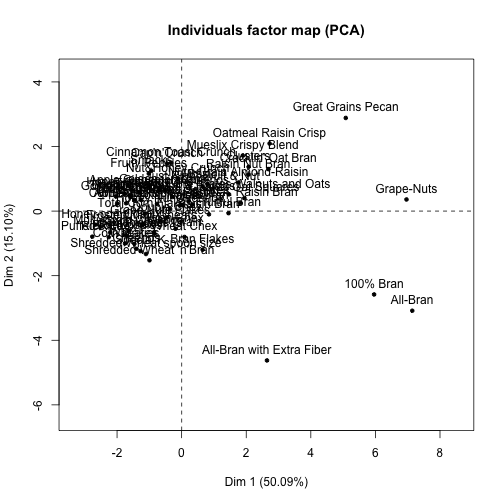

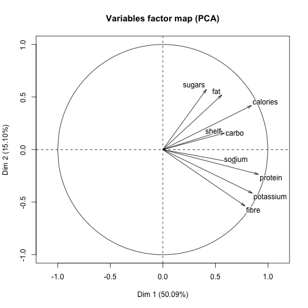

```r
# PCA can only be done on numeric variables
numericcols <- sapply(UScereal, is.numeric)
# Perform PCA, skip the plots for now
cereal.pca <- PCA(UScereal[numericcols])
```

### Interpreting PCA

#### Eigenvalues

The **eigenvalue** of a principal component is the amount of variance explained by that component. These are in order, so the first eigenvalue will be the largest and so on. We can retrieve them from `cereal.pca$eig`.

```r
cereal.pca$eig
```

```
##        eigenvalue percentage of variance cumulative percentage of variance
## comp 1   4.507994               50.08882                             50.09
## comp 2   1.359057               15.10063                             65.19
## comp 3   1.194672               13.27413                             78.46
## comp 4   0.738865                8.20961                             86.67
## comp 5   0.593874                6.59860                             93.27
## comp 6   0.468633                5.20704                             98.48
## comp 7   0.101423                1.12692                             99.61
## comp 8   0.028421                0.31579                             99.92
## comp 9   0.007062                0.07847                            100.00
```

As we can see, we've gotten 9 PCs from the data, ordered by the amount of variance explained by the component. The first accounts for 50.0888% of the variance in the data. The first three PCs account for 78.4636% of the data. All of the PCs explain all of the variance in the data.

#### How many components should I use?

The eigenvalues of the PCs tell us how many it is useful to retain or examine. But there's not a really good way to objectively get it. No rigorous way to choose, but here are some options:

- **Kaiser rule**: Only keep PCs with eigenvalues over 1. An eigenvalue greater than one indicates that a PC accounts for more of the variance than one of the original predictors and you've successfully reduced dimensionality.
- **Screeplot**: Plot the eigenvalues of PCs in order and look for an elbow (where the line bends into a flat plane, indicating random noise)

```r
# A function to make a prettier screeplot than you'd get with default
# graphics
fmscree <- function(PCAobj) {
    df <- as.data.frame(PCAobj$eig)
    df$component <- seq(1, nrow(df))
    plot <- ggplot(df, aes(x = component, y = eigenvalue)) + geom_point(size = 3) +
        geom_line()
    plot <- plot + geom_hline(yintercept = 1, color = "red", lty = "dotted")
    print(plot)
}
```

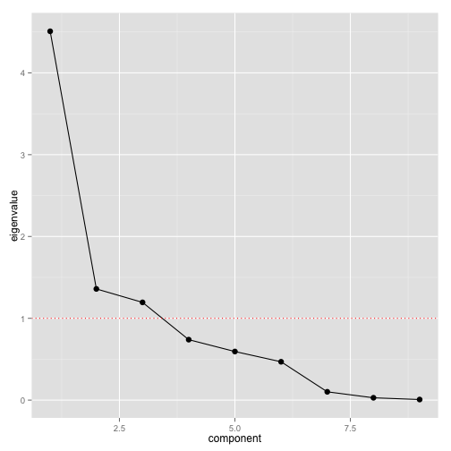

```r
fmscree(cereal.pca)
```

#### Loadings

The **loadings** describe the relationships of the *variable* to each of the components. A positive value for a loading indicates that an increased value for that variable results in an increased value for that PC. Variable level information is available in `cereal.pca$var`. The loadings themselves are in `cereal.pca$var$coord`.

```r
cereal.pca$var$coord
```

```
##            Dim.1   Dim.2    Dim.3     Dim.4     Dim.5
## calories  0.8435  0.4190 -0.27970 -0.056451  0.008425
## protein   0.9106 -0.2351 -0.08269 -0.013654 -0.152761
## fat       0.5610  0.5195  0.21762 -0.090330 -0.541080
## sodium    0.6960 -0.1273 -0.16472 -0.360982  0.337697
## fibre     0.7809 -0.5359  0.24877 -0.001072 -0.066369
## carbo     0.5860  0.1571 -0.76765  0.098056  0.038199
## sugars    0.4144  0.5722  0.52017 -0.227678  0.342911
## shelf     0.5648  0.1765  0.19356  0.731655  0.198482
## potassium 0.8510 -0.4144  0.27550 -0.015867 -0.028513
```

FactoMineR has a convenient way of plotting loadings, by calling `plot` on PCA objects.

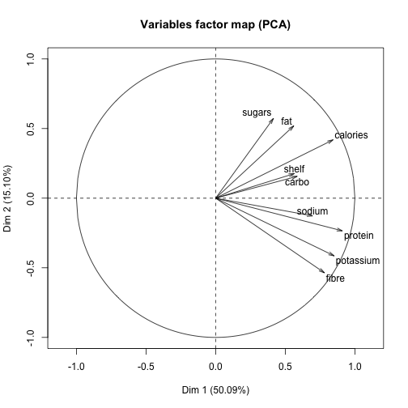

```r
# choix chooses between individuals and variables.  Its 'choix' because the
# FactoMineR people are French.
plot(cereal.pca, choix = "var")
```

When you look at the plot you can already see a divide between sugary cereals (higher scores on PC2) vs fibery cereals (lower scores on PC2), but its hard to say anything about PC1, since all of the loadings are positive.

#### Contributions

Related to the loadings, the **contributions** describe how much of a PC is due to a variable. These are available in `cereal.pca$var$contrib`.

```r
round(cereal.pca$var$contrib, 2)
```

```
##           Dim.1 Dim.2 Dim.3 Dim.4 Dim.5
## calories  15.78 12.92  6.55  0.43  0.01
## protein   18.39  4.07  0.57  0.03  3.93
## fat        6.98 19.86  3.96  1.10 49.30
## sodium    10.75  1.19  2.27 17.64 19.20
## fibre     13.53 21.13  5.18  0.00  0.74
## carbo      7.62  1.82 49.33  1.30  0.25
## sugars     3.81 24.09 22.65  7.02 19.80
## shelf      7.08  2.29  3.14 72.45  6.63
## potassium 16.06 12.63  6.35  0.03  0.14
```

#### PC Scores

The **PC score** describes where on the PC an *observation* is. This is typically the most useful part of PCA, because it describes where your sample is in the reduced-dimension principal component space. Plotting them is the usual thing to do. If you have useful labels, use them in the plot.

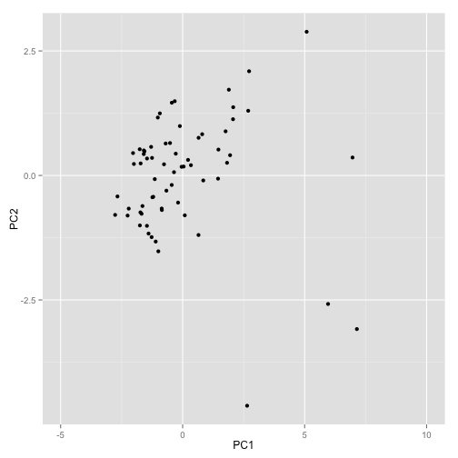

```r
# You can plot, just like before with plot(cereal.pca,choix='ind') but the
# labels get a little crowded so I'm going to use ggplot
scoredf <- data.frame(PC1 = cereal.pca$ind$coord[, 1], PC2 = cereal.pca$ind$coord[,
    2], brand = rownames(UScereal))
ggplot(scoredf, aes(x = PC1, y = PC2, label = brand)) + geom_point() + xlim(-5,
    10)
```

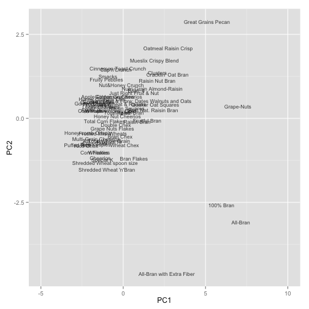

```r
ggplot(scoredf, aes(x = PC1, y = PC2, label = brand)) + geom_text(size = 3,
    alpha = 0.75) + xlim(-5, 10)
```

With how long the labels are, the graph of the PCs is hard to read. Maybe we'll get some insight on PC1 by looking at the extremes of the distribution.

```r
summary(scoredf$PC1)
```

```
##    Min. 1st Qu.  Median    Mean 3rd Qu.    Max.
##  -2.770  -1.460  -0.666   0.000   0.801   7.140
```

```r
Q1 <- summary(scoredf$PC1)[["1st Qu."]]
Q3 <- summary(scoredf$PC1)[["3rd Qu."]]
# The low scorers
subset(scoredf, PC1 < Q1, select = c(PC1, PC2))
```

```
##                         PC1     PC2
## Apple Jacks          -1.722  0.2416
## Cocoa Puffs          -1.590  0.5019
## Corn Chex            -1.730 -0.7413
## Corn Flakes          -1.753 -1.0040
## Corn Pops            -1.998  0.2303
## Count Chocula        -1.567  0.4820
## Froot Loops          -1.594  0.4294
## Golden Crisp         -2.034  0.4493
## Honey-comb           -2.671 -0.4217
## Kix                  -2.210 -0.6659
## Multi-Grain Cheerios -1.647 -0.6143
## Puffed Rice          -2.767 -0.7922
## Rice Chex            -2.257 -0.8058
## Rice Krispies        -1.682 -0.7696
## Trix                 -1.759  0.5265
## Wheaties             -1.464 -1.0119
```

```r
# The high scorers
subset(scoredf, PC1 > Q3, select = c(PC1, PC2))
```

```
##                                          PC1      PC2
## 100% Bran                             5.9600 -2.58111
## All-Bran                              7.1416 -3.08459
## All-Bran with Extra Fiber             2.6422 -4.62435
## Clusters                              2.0732  1.37038
## Cracklin' Oat Bran                    2.6876  1.29875
## Fruit & Fibre: Dates Walnuts and Oats 1.4667  0.51943
## Fruitful Bran                         1.4513 -0.06441
## Grape-Nuts                            6.9624  0.36009
## Great Grains Pecan                    5.0824  2.88487
## Mueslix Crispy Blend                  1.8938  1.72182
## Nutri-Grain Almond-Raisin             1.7604  0.88614
## Oatmeal Raisin Crisp                  2.7234  2.09258
## Post Nat. Raisin Bran                 1.8195  0.25373
## Quaker Oat Squares                    1.9441  0.40633
## Raisin Bran                           0.8451 -0.10079
## Raisin Nut Bran                       2.0654  1.12906
```

Interpreting PCs is always subjective, but looking at this I think it's clear that PC1 is separating kid's cereal (Fruit Loops, Count Chocula) from grown up cereal (All the bran cereals). An equally valid interpretation is that PC1 is separating candy cereals from healthy cereals.

What about PC2?

```r
summary(scoredf$PC2)
```

```
##    Min. 1st Qu.  Median    Mean 3rd Qu.    Max.
##  -4.620  -0.666   0.224   0.000   0.574   2.880
```

```r
Q1 <- summary(scoredf$PC2)[["1st Qu."]]
Q3 <- summary(scoredf$PC2)[["3rd Qu."]]
# The low scorers
subset(scoredf, PC2 < Q1, select = c(PC1, PC2))
```

```
##                                PC1     PC2
## 100% Bran                  5.96001 -2.5811
## All-Bran                   7.14164 -3.0846
## All-Bran with Extra Fiber  2.64216 -4.6244
## Bran Flakes                0.64965 -1.1962
## Cheerios                  -1.39716 -1.1670
## Corn Chex                 -1.73009 -0.7413
## Corn Flakes               -1.75266 -1.0040
## Product 19                -0.85156 -0.6939
## Puffed Rice               -2.76741 -0.7922
## Rice Chex                 -2.25670 -0.8058
## Rice Krispies             -1.68239 -0.7696
## Shredded Wheat 'n'Bran    -0.99629 -1.5235
## Shredded Wheat spoon size -1.10435 -1.3276
## Special K                 -1.27171 -1.2382
## Wheat Chex                 0.08802 -0.8006
## Wheaties                  -1.46383 -1.0119
```

```r
# The high scorers
subset(scoredf, PC2 > Q3, select = c(PC1, PC2))
```

```
##                               PC1    PC2
## Apple Cinnamon Cheerios   -0.6964 0.6418
## Basic 4                    0.8008 0.8282
## Cap'n'Crunch              -0.4447 1.4604
## Cinnamon Toast Crunch     -0.3240 1.4909
## Clusters                   2.0732 1.3704
## Cracklin' Oat Bran         2.6876 1.2988
## Fruity Pebbles            -1.0184 1.1628
## Golden Grahams            -0.5170 0.6507
## Great Grains Pecan         5.0824 2.8849
## Just Right Fruit & Nut     0.6535 0.7561
## Mueslix Crispy Blend       1.8938 1.7218
## Nut&Honey Crunch          -0.1140 0.9913
## Nutri-Grain Almond-Raisin  1.7604 0.8861
## Oatmeal Raisin Crisp       2.7234 2.0926
## Raisin Nut Bran            2.0654 1.1291
## Smacks                    -0.9345 1.2464
```

This one is not as clear as the others, but by looking at this in combination with the loadings for PC2 from the previous section, we can say that that PC2 is separating sugary cereals and fibery cereals.

You can keep digging through for more information from additional PCs, but I couldn't pick out a good pattern from the loadings for PC3 (lower for increased calories but higher for increased sugar?), and since it already has a low eigenvalue (1.1947), I'll call the rest of the variation noise.

## More Examples

### Comparing cars by their specs.

```r
data(mtcars)
symnum(cor(mtcars[, -c(8, 9)]))
```

```
##      m cy ds h dr w q g cr
## mpg  1
## cyl  + 1
## disp + *  1
## hp   , +  ,  1
## drat , ,  ,  . 1
## wt   + ,  +  , ,  1
## qsec . .  .  ,      1
## gear . .  .    ,  .   1
## carb . .  .  ,    . ,   1
## attr(,"legend")
## [1] 0 ' ' 0.3 '.' 0.6 ',' 0.8 '+' 0.9 '*' 0.95 'B' 1
```

Let's see what comes up in the PCA

```r
mtcars.pca <- PCA(mtcars[, -c(8, 9)], graph = F)
summary(mtcars.pca)
```

```
##
## Call:
## knit("dimensionality_reduction.Rmd", encoding = "UTF-8")
##
##
## Eigenvalues
##                        Dim.1   Dim.2   Dim.3   Dim.4   Dim.5   Dim.6
## Variance               5.656   2.082   0.504   0.265   0.183   0.124
## % of var.             62.844  23.134   5.602   2.945   2.035   1.375
## Cumulative % of var.  62.844  85.978  91.581  94.525  96.560  97.936
##                        Dim.7   Dim.8   Dim.9
## Variance               0.105   0.059   0.022
## % of var.              1.167   0.650   0.247
## Cumulative % of var.  99.103  99.753 100.000
##
## Individuals (the 10 first)
##                       Dist    Dim.1    ctr   cos2    Dim.2    ctr   cos2
## Mazda RX4         |  1.658 | -0.675  0.252  0.166 |  1.192  2.133  0.517 |
## Mazda RX4 Wag     |  1.446 | -0.647  0.232  0.200 |  0.993  1.479  0.471 |
## Datsun 710        |  2.485 | -2.337  3.016  0.884 | -0.332  0.165  0.018 |
## Hornet 4 Drive    |  2.094 | -0.219  0.026  0.011 | -2.008  6.054  0.920 |
## Hornet Sportabout |  2.138 |  1.612  1.436  0.569 | -0.842  1.064  0.155 |
## Valiant           |  2.667 |  0.050  0.001  0.000 | -2.486  9.275  0.869 |
## Duster 360        |  2.949 |  2.758  4.202  0.875 |  0.367  0.202  0.015 |
## Merc 240D         |  2.470 | -2.076  2.382  0.707 | -0.813  0.993  0.108 |
## Merc 230          |  3.459 | -2.332  3.004  0.454 | -1.326  2.641  0.147 |
## Merc 280          |  1.290 | -0.389  0.083  0.091 |  0.590  0.523  0.209 |
##                    Dim.3    ctr   cos2
## Mazda RX4         -0.208  0.267  0.016 |
## Mazda RX4 Wag      0.113  0.079  0.006 |
## Datsun 710        -0.214  0.283  0.007 |
## Hornet 4 Drive    -0.335  0.694  0.026 |
## Hornet Sportabout -1.050  6.827  0.241 |
## Valiant            0.114  0.080  0.002 |
## Duster 360        -0.662  2.720  0.050 |
## Merc 240D          0.863  4.611  0.122 |
## Merc 230           2.000 24.791  0.334 |
## Merc 280           0.901  5.026  0.487 |
##
## Variables
##                      Dim.1    ctr   cos2    Dim.2    ctr   cos2    Dim.3
## mpg               | -0.935 15.457  0.874 |  0.040  0.076  0.002 | -0.157
## cyl               |  0.957 16.205  0.917 |  0.023  0.025  0.001 | -0.179
## disp              |  0.945 15.789  0.893 | -0.128  0.790  0.016 | -0.056
## hp                |  0.873 13.475  0.762 |  0.389  7.258  0.151 | -0.012
## drat              | -0.742  9.723  0.550 |  0.493 11.673  0.243 |  0.106
## wt                |  0.888 13.949  0.789 | -0.248  2.956  0.062 |  0.322
## qsec              | -0.534  5.033  0.285 | -0.698 23.430  0.488 |  0.446
## gear              | -0.498  4.388  0.248 |  0.795 30.336  0.632 |  0.147
## carb              |  0.582  5.982  0.338 |  0.699 23.456  0.488 |  0.330
##                      ctr   cos2
## mpg                4.893  0.025 |
## cyl                6.366  0.032 |
## disp               0.612  0.003 |
## hp                 0.030  0.000 |
## drat               2.249  0.011 |
## wt                20.587  0.104 |
## qsec              39.454  0.199 |
## gear               4.268  0.022 |
## carb              21.541  0.109 |
```

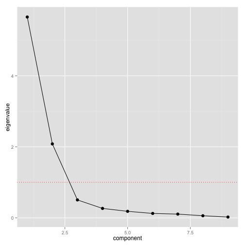

```r
# Make a screeplot to visualize the eigenvalues
fmscree(mtcars.pca)
```

Looking at the Scree plot, its clear that there are only two major principal components, accounting for 85% of the total variance in the dataset. What do they represent?

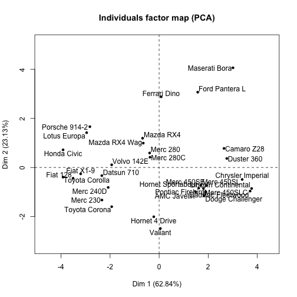

```r
# choix tells whether to plot individual PC scores or PC loadings for
# variables
plot(mtcars.pca, choix = "ind")
```

Just by eyeballing it, you can see that PC1 (accounting for ~63% of the variance in the dataset) measures the 'fanciness' of the car, as well as it can by specs and performance. In the negative direction you have economy cars, like Hondas and Fiats, as well as a few higher end models which have lower specification. On the other end you have higher end luxury cars: Maseratis, Chryslers, Cadillacs, etc.

Principal component 2 seems to separate cars based on performance. The Ferrari, Maserati, and the Pantera (a sports car) all have high scores on this PC. On the other hand, you have cars like the Toyota Corona, the Hornet, and especially the Valiant are very poorly performing cars.

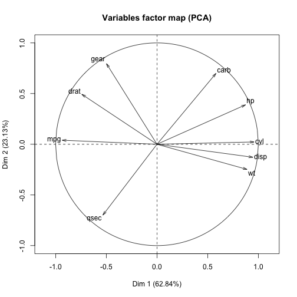

```r
plot(mtcars.pca, choix = "var")
```

This plot shows the relationship of the *variables* to the two principal components. Cars that get better mileage are usually economy cars, and mpg shows that. A larger value for mpg results in a lower score on PC1 (the fancy car PC). On the other hand, fancier cars usually have bigger engines, and larger numbers of cylinders, increased displacement, and weight all results in a higher score on PC1.

Cars that perform poorly on the quarter mile get lower scores on PC2. These are also typically the lower spec'ed cars, so increased values of qsec result in lower scores also get you a lower score on PC1. The opposite is true for number of carbs and horsepower.

### Outlier detection: The Florida 2000 election.

It can be hard to identify outliers in high dimensional spaces, where there are so many things going on. A great place to look for weird things happening is the 2000 Florida election, where weird things did happen. The dataset `Florida` in package `car` has vote counts for each florida county, for 10 presidential candidates. What happens when you look at the vote counts with PCA.

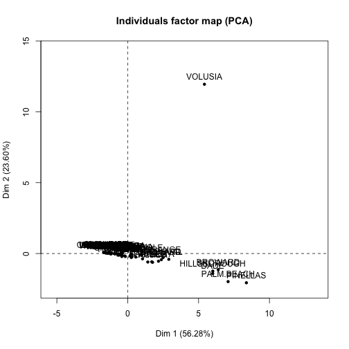

```r
data(Florida, package = "car")
fl.pca <- PCA(Florida[1:10], graph = F)
plot(fl.pca, choix = "ind")
```

Lets look at the first two PCs. So theres an expected group around 0,0. And you can see the large population counties (Dade, Hillsborough, etc) off a little farther. They're going to separate out in any analysis not normalized by population size because their populations are so much larger than the other counties. But the real star of this plot is Volusia county, which is far, far away on PC2 from the rest of the counties.

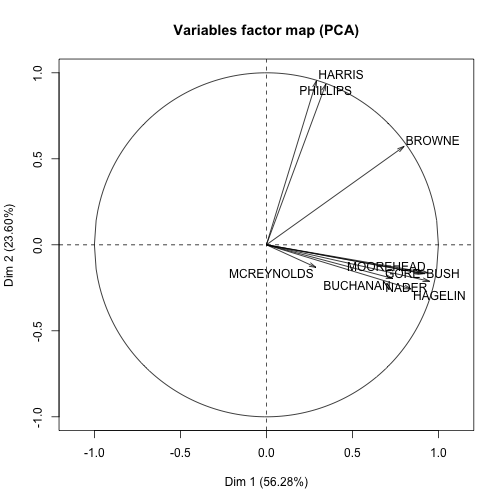

```r
plot(fl.pca, choix = "var")
```

When we look at the variable plot, we see that high scores on PC2 are driven by voting for some people I've never heard of (Harris, Phillips, Browne). So that's a big hint that somethings up. Lets compare Volusia to two (geographically) nearby counties, Flagler and Seminole.

```r
# We'll look at the percents too.
Florida.percent <- round(100 * Florida[1:10]/Florida[, "Total"], 3)

volusia.neighbors <- c("VOLUSIA", "SEMINOLE", "FLAGLER", "LAKE", "PUTNAM", "MARION",
    "ORANGE")
Florida[volusia.neighbors, c("GORE", "BUSH", "PHILLIPS", "HARRIS", "BROWNE")]
```

```
##            GORE   BUSH PHILLIPS HARRIS BROWNE
## VOLUSIA   97063  82214     2927   9888   3211
## SEMINOLE  58888  75293       27     38    551
## FLAGLER   13891  12608        3      1     60
## LAKE      36555  49963       21      4    203
## PUTNAM    12091  13439       10      2    114
## MARION    44648  55135       22     14    361
## ORANGE   140115 134476       41     13    892
```

```r
Florida.percent[volusia.neighbors, c("GORE", "BUSH", "PHILLIPS", "HARRIS", "BROWNE")]
```

```
##           GORE  BUSH PHILLIPS HARRIS BROWNE
## VOLUSIA  48.97 41.47    1.477  4.988  1.620
## SEMINOLE 42.97 54.94    0.020  0.028  0.402
## FLAGLER  51.26 46.52    0.011  0.004  0.221
## LAKE     41.28 56.43    0.024  0.005  0.229
## PUTNAM   46.14 51.28    0.038  0.008  0.435
## MARION   43.50 53.72    0.021  0.014  0.352
## ORANGE   50.04 48.03    0.015  0.005  0.319
```

So it looks like the variable causing the issue is too many people voting for Harris than you might expect, given the surrounding counties. For comparison, the median number of votes for Harris per county was 4.

In 2000, Volusia county's computers had an error that (among other things) gave 9888 erroneous votes to James Harris, the Socialist Workers Party candidate for president. [Here's a New York Times article on it](http://www.nytimes.com/2000/11/10/us/2000-campaign-florida-vote-democrats-tell-problems-polls-across-florida.html?pagewanted=all&src=pm)

What about principal component #3? It still explains 10% of the variance, and has an eigenvalue (slightly) greater than 1. Let's see if there's anything interesting going on there. Let's look at components 1 and 3 together (we already pretty much know what's gone on with PC2 already).

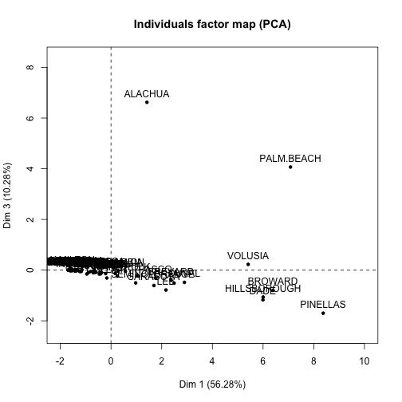

```r
plot(fl.pca, axes = c(1, 3), choix = "ind")
```

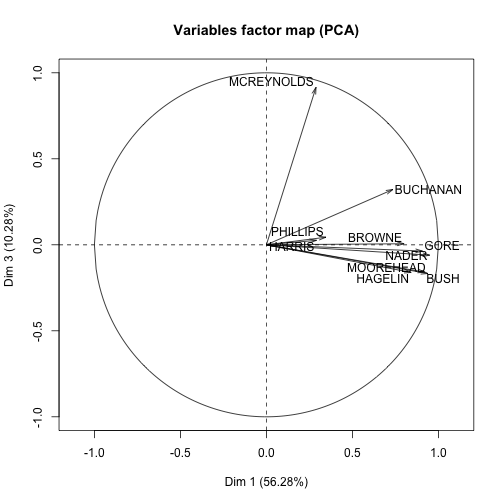

```r
plot(fl.pca, axes = c(1, 3), choix = "var")
```

```r
alachua.neighbors <- c("ALACHUA", "BRADFORD", "UNION", "LEVY", "PUTNAM", "CLAY",
    "COLUMBIA", "GILCHRIST")
Florida[alachua.neighbors, c("GORE", "BUSH", "MCREYNOLDS", "BUCHANAN")]
```

```
##            GORE  BUSH MCREYNOLDS BUCHANAN
## ALACHUA   47300 34062        658      262
## BRADFORD   3072  5413          0       65
## UNION      1399  2326          0       26
## LEVY       5403  6860          1       67
## PUTNAM    12091 13439          4      147
## CLAY      14630 41745          3      186
## COLUMBIA   7047 10964          2       89
## GILCHRIST  1910  3300          0       29
```

```r
Florida.percent[alachua.neighbors, c("GORE", "BUSH", "MCREYNOLDS", "BUCHANAN")]
```

```
##            GORE  BUSH MCREYNOLDS BUCHANAN
## ALACHUA   54.85 39.50      0.763    0.304
## BRADFORD  35.44 62.44      0.000    0.750
## UNION     36.87 61.31      0.000    0.685
## LEVY      42.44 53.89      0.008    0.526
## PUTNAM    46.14 51.28      0.015    0.561
## CLAY      25.51 72.78      0.005    0.324
## COLUMBIA  38.08 59.24      0.011    0.481
## GILCHRIST 35.40 61.17      0.000    0.538
```

Alachua has alot more votes for McReynolds than the surrounding counties (even if it only comes out to 0.763%). It's also the home of the University of Florida. Since he's the socialist candidate, I'm pretty comfortable chalking that up to college students' votes.

```r
# I'm going with similar counties instead of neighbors, because I think St.
# Lucie is more like Palm Beach than, say, Hendry County
palmbeach.similar <- c("PALM.BEACH", "BROWARD", "ST.LUCIE", "MARTIN", "DADE")
Florida[palmbeach.similar, c("GORE", "BUSH", "MCREYNOLDS", "BUCHANAN")]
```

```
##              GORE   BUSH MCREYNOLDS BUCHANAN
## PALM.BEACH 268945 152846        302     3407
## BROWARD    386518 177279         35      789
## ST.LUCIE    41559  34705         10      124
## MARTIN      26619  33864          8      108
## DADE       328702 289456         36      561
```

```r
Florida.percent[palmbeach.similar, c("GORE", "BUSH", "MCREYNOLDS", "BUCHANAN")]
```

```
##             GORE  BUSH MCREYNOLDS BUCHANAN
## PALM.BEACH 62.22 35.36      0.070    0.788
## BROWARD    67.42 30.92      0.006    0.138
## ST.LUCIE   53.29 44.50      0.013    0.159
## MARTIN     43.04 54.75      0.013    0.175
## DADE       52.57 46.29      0.006    0.090
```

Palm Beach on the other had got way more votes for Buchanan than similar counties (even Broward and Dade, which have larger populations). Palm Beach used butterfly ballots which were thought to confuse voters, who intending to vote for Gore voted for Pat Buchanan. This was a major point of contention in tallying votes. [Here's a Wikipedia page on it](http://en.wikipedia.org/wiki/United_States_presidential_election,_2000_Florida_results#Palm_Beach_County.27s_butterfly_ballots).

### Crabs: reducing many size measurements into a one dimensional feature space

```r
data(crabs, package = "MASS")
head(crabs)
```

```
##   sp sex index   FL  RW   CL   CW  BD
## 1  B   M     1  8.1 6.7 16.1 19.0 7.0
## 2  B   M     2  8.8 7.7 18.1 20.8 7.4
## 3  B   M     3  9.2 7.8 19.0 22.4 7.7
## 4  B   M     4  9.6 7.9 20.1 23.1 8.2
## 5  B   M     5  9.8 8.0 20.3 23.0 8.2
## 6  B   M     6 10.8 9.0 23.0 26.5 9.8
```

```r
# These are our variables of interest
sizevars <- 4:8
```

```r
round(cor(crabs[sizevars]), 2)
```

```
##      FL   RW   CL   CW   BD
## FL 1.00 0.91 0.98 0.96 0.99
## RW 0.91 1.00 0.89 0.90 0.89
## CL 0.98 0.89 1.00 1.00 0.98
## CW 0.96 0.90 1.00 1.00 0.97
## BD 0.99 0.89 0.98 0.97 1.00
```

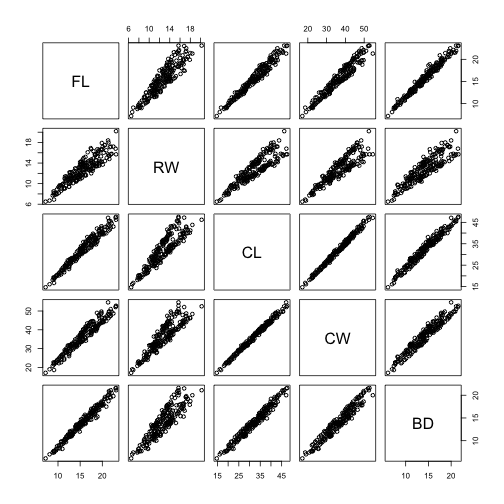

```r
plot(crabs[sizevars])
```

Lets do the PCA anyway and take a look around:

```r
c.pca <- PCA(crabs[sizevars], graph = F)
summary(c.pca)
```

```
##
## Call:
## knit("dimensionality_reduction.Rmd", encoding = "UTF-8")
##
##
## Eigenvalues
##                        Dim.1   Dim.2   Dim.3   Dim.4   Dim.5
## Variance               4.789   0.152   0.047   0.011   0.002
## % of var.             95.777   3.034   0.933   0.223   0.034
## Cumulative % of var.  95.777  98.810  99.743  99.966 100.000
##
## Individuals (the 10 first)
##        Dist    Dim.1    ctr   cos2    Dim.2    ctr   cos2    Dim.3    ctr
## 1  |  4.937 | -4.928  2.535  0.996 | -0.268  0.238  0.003 | -0.122  0.160
## 2  |  4.387 | -4.386  2.009  0.999 | -0.094  0.029  0.000 | -0.039  0.017
## 3  |  4.133 | -4.129  1.780  0.998 | -0.169  0.094  0.002 |  0.034  0.012
## 4  |  3.892 | -3.884  1.575  0.996 | -0.246  0.199  0.004 |  0.015  0.002
## 5  |  3.841 | -3.834  1.535  0.996 | -0.224  0.166  0.003 | -0.015  0.002
## 6  |  2.962 | -2.953  0.910  0.994 | -0.220  0.160  0.006 |  0.038  0.016
## 7  |  2.680 | -2.678  0.749  0.999 |  0.039  0.005  0.000 |  0.082  0.072
## 8  |  2.575 | -2.548  0.678  0.979 | -0.363  0.435  0.020 |  0.063  0.042
## 9  |  2.593 | -2.585  0.698  0.994 | -0.117  0.045  0.002 |  0.062  0.042
## 10 |  2.213 | -2.206  0.508  0.994 |  0.079  0.021  0.001 |  0.157  0.264
##      cos2
## 1   0.001 |
## 2   0.000 |
## 3   0.000 |
## 4   0.000 |
## 5   0.000 |
## 6   0.000 |
## 7   0.001 |
## 8   0.001 |
## 9   0.001 |
## 10  0.005 |
##
## Variables
##       Dim.1    ctr   cos2    Dim.2    ctr   cos2    Dim.3    ctr   cos2
## FL |  0.989 20.434  0.979 | -0.054  1.893  0.003 | -0.115 28.172  0.013 |
## RW |  0.937 18.325  0.878 |  0.350 80.664  0.122 |  0.003  0.014  0.000 |
## CL |  0.992 20.538  0.984 | -0.104  7.195  0.011 |  0.067  9.590  0.004 |
## CW |  0.987 20.350  0.975 | -0.070  3.261  0.005 |  0.141 42.585  0.020 |
## BD |  0.987 20.352  0.975 | -0.103  6.987  0.011 | -0.096 19.639  0.009 |
```

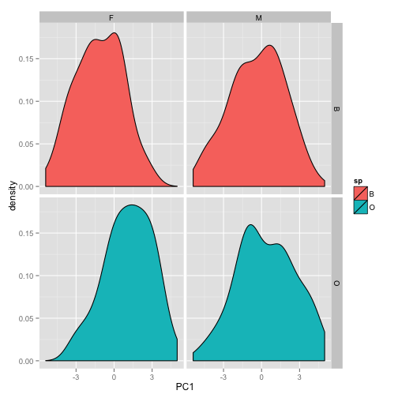

```r
c <- crabs
c$PC1 <- c.pca$ind$coord[, 1]
ggplot(c, aes(x = PC1, fill = sp)) + geom_density() + facet_grid(sp ~ sex)
```

### Reducing dimensionality before clustering

```r
library(cluster)
data(car90, package = "rpart")
# We only want the numeric predictors
car90n <- car90[, sapply(car90, is.numeric)]
```

Just *a priori*, I'll say there are three classes of cars in the dataset. Let's run the classifier.

```r
# Calculate the distances
car90n.dist <- daisy(car90n)
car90n.pam <- pam(car90n.dist, k = 3)
```

The point of classification is that an observation in class A should be more similar to other points in class A than to points in other classes. A good measure of this is the **silhouette**, which looks at those similarities. A silhouette maximizes at 1, and a negative value indicates that a data point is probably misclassified (it's more similar to points in other classes than its own.) You can also look at average silhouettes in a class as a measure of how well fit that class is. We can plot silhouettes with `plot` on the object returned from `pam`.

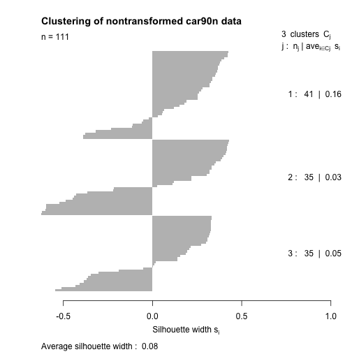

```r
plot(car90n.pam, main = "Clustering of nontransformed car90n data")
```

The bars on the chart represents the silhoutte for each datapoint. Its obvious that alot of points are not classified well. On the right hand side you can see the sizes and average silhoutte for the cluster. Clusters 2 and 3 do terrible jobs of classifying the data and class 1 isnt so hot either. So that classification didn't do well. But we already know that cars *do* come in different classes. That's how they're manufactured. Sports cars are different than sedans. SUVs and vans come on truck frames and should class together alot of the time if you're going by specs. So what's going on?

#### The curse of dimensionality

What's happening is the *curse of dimensionality*, which is when non-intuitive things start happening when dealing with large predictor datasets. This can be a problem for kNN classifiers (like `pam`), in two different ways.

- **Distances**: One of the big problems for nearest-neighbor approaches in high dimensions is that the euclidiean distance formula \[ D(p,q)=\sqrt[n]{(q_{1} - p_{1})^{2} + (q_{2} - p_{2})^{2} + \cdots + (q_{n} - p_{n})^{2}} \] considers *all* the features. As you add more features, distances become larger, and you have to go farther and farther to find those nearest neighbors. This can often result in picking a neighbor with the 'wrong' class, and soon your classification system is shot, because pretty much every datapoint has a neighbor in the wrong class.
- **Noise**: The other big problem is that kNN approaches consider all of the predictors when doing the classification. I know this sounds like the last bullet point but it's also bad for a different reason. If the predictors are noisy, that noise is reflected in the the classifications. If you have a predictor that should be completely unrelated to the class, that will be reflected in the classification too.

If the main advantages of PCA are *dimensionality reduction* (by keeping the PCs that explain a large proportion of variance) and *noise reduction* (by ignoring the extraneous PCs that don't explain much variance), it looks like it might be something that can help remedy these problems. Lets try projecting the `car90` data down into a lower dimensionality space.

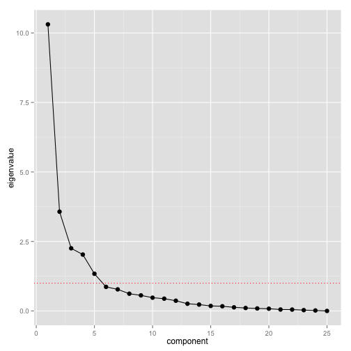

```r
car90n.pca <- PCA(car90n, graph = F, ncp = 5)
fmscree(car90n.pca)
```

There are 5 major PCs in the data, going by either the screeplot or the Kaiser rule. I've kept data on the 5 PCs in the output of `PCA` with the `ncp` flag. Let's try clustering *that* data and looking at how the clustering goes.

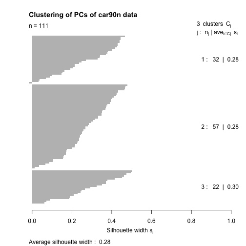

```r
car90n.pca.dist <- daisy(car90n.pca$ind$coord)
car90n.pca.pam <- pam(car90n.pca.dist, k = 3)
plot(car90n.pca.pam, main = "Clustering of PCs of car90n data")
```

This way is a lot better! The average silhouttes are much higher and theres only one value that looks misclassified.

### You can get prinicpal components out of nothing.

Principal components can always be found. That doesn't necessarily mean they mean something. Here's some randomly generated data: 200 'observations' of 5 variables, all random normal variates.

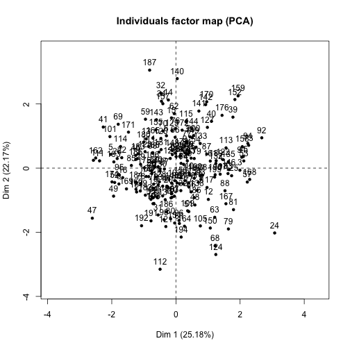

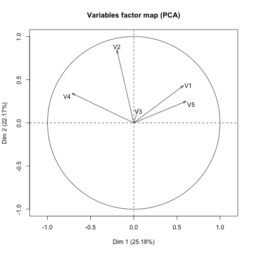

```
##
## Call:
## knit("dimensionality_reduction.Rmd", encoding = "UTF-8")
##
##
## Eigenvalues
##                        Dim.1   Dim.2   Dim.3   Dim.4   Dim.5
## Variance               1.259   1.108   0.997   0.883   0.752
## % of var.             25.183  22.169  19.942  17.662  15.044
## Cumulative % of var.  25.183  47.352  67.294  84.956 100.000
##
## Individuals (the 10 first)
##        Dist    Dim.1    ctr   cos2    Dim.2    ctr   cos2    Dim.3    ctr
## 1  |  3.002 | -2.573  2.628  0.735 |  0.244  0.027  0.007 | -0.182  0.017
## 2  |  2.406 | -0.128  0.006  0.003 | -0.797  0.286  0.110 | -0.930  0.434
## 3  |  3.192 |  1.994  1.579  0.390 | -0.066  0.002  0.000 | -1.180  0.699
## 4  |  1.916 |  1.393  0.771  0.529 |  0.096  0.004  0.003 | -0.724  0.263
## 5  |  2.849 | -2.031  1.637  0.508 |  0.427  0.082  0.022 | -1.565  1.229
## 6  |  1.907 | -0.296  0.035  0.024 |  1.009  0.459  0.280 | -0.804  0.324
## 7  |  2.194 | -0.527  0.110  0.058 |  0.498  0.112  0.051 | -1.616  1.309
## 8  |  2.476 | -1.778  1.255  0.516 | -0.495  0.110  0.040 | -1.172  0.689
## 9  |  1.623 |  0.279  0.031  0.030 |  0.684  0.211  0.178 | -0.638  0.204
## 10 |  2.777 |  0.416  0.069  0.022 | -0.160  0.012  0.003 |  1.990  1.986
##      cos2
## 1   0.004 |
## 2   0.149 |
## 3   0.137 |
## 4   0.143 |
## 5   0.302 |
## 6   0.178 |
## 7   0.542 |
## 8   0.224 |
## 9   0.155 |
## 10  0.514 |
##
## Variables
##       Dim.1    ctr   cos2    Dim.2    ctr   cos2    Dim.3    ctr   cos2
## V1 |  0.576 26.393  0.332 |  0.432 16.803  0.186 | -0.133  1.773  0.018 |
## V2 | -0.195  3.015  0.038 |  0.845 64.439  0.714 | -0.106  1.125  0.011 |
## V3 |  0.054  0.232  0.003 |  0.165  2.464  0.027 |  0.983 96.963  0.967 |
## V4 | -0.717 40.844  0.514 |  0.343 10.616  0.118 | -0.026  0.069  0.001 |
## V5 |  0.610 29.516  0.372 |  0.251  5.678  0.063 | -0.026  0.069  0.001 |
```

```r
summary(PCA(matrix(rnorm(1000), ncol = 5)))
```

## Special cases and related concepts

- Sparse PCA
- Principal component regression